# SVM,KNN,K-Means and Hiearchical Clustering Analysis

### Importing All Neccessary Libraries

All these libraries are necessary to carry out the tasks performed in this notebook. I have categorised the libraries so that its easier for you to understand where we have used which library.

```python
## Baysian
import math # Applying Mathematical Functions
import numpy as np # For arrays
import random # Used in initial sample function

#from random import sample
from matplotlib import pyplot as plt # For Plots
import seaborn as sns # For Creating Plots
from scipy.stats import norm # For Normalization
from sklearn.gaussian_process import GaussianProcessRegressor # Gaussian Process Regression Model
from sklearn.gaussian_process.kernels import RBF # Regression Process Kernel

## Classification and Clustering Both
import pandas as pd # Importing and manipulating the dataset
from sklearn.preprocessing import StandardScaler # Standardized the Features of each column
from sklearn.model_selection import train_test_split # Split the dataset into test and train

# Classification
from sklearn.pipeline import Pipeline # Create pipeline to standardized and create classification model
from sklearn.neighbors import KNeighborsClassifier # KNN Algorithm
from sklearn.svm import SVC # SVM Algorithm
from sklearn.metrics import classification_report,confusion_matrix,accuracy_score # Evaluation Libraries
from sklearn.model_selection import GridSearchCV # Parameter-Tuning to Improve performance of model.

#Clustering
from sklearn.cluster import AgglomerativeClustering # Hierarchial CLustering
from scipy.cluster.hierarchy import linkage # Creating Dendogram
from sklearn.cluster import KMeans # KMeans Clustering
from scipy.spatial import distance_matrix # Matrix for Creating Dendogram
from scipy.cluster import hierarchy
from sklearn.metrics import davies_bouldin_score # clustering validity indices
from sklearn.metrics import silhouette_score # clustering validity indices
from sklearn.metrics import silhouette_samples # clustering validity indices
from sklearn import metrics # clustering validity indices


import warnings # Ignore any warnings
warnings.filterwarnings("ignore")
```

### Part 1 Bayesian Machine Learning

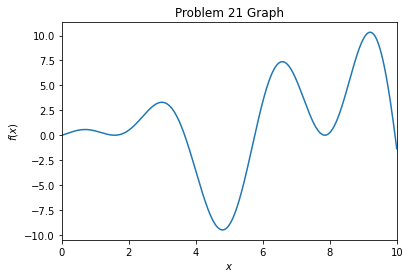

```python
# This is the test function on which we will be applying baysian optimization
def Problem21(x):
 val = x*math.sin(x) + x*math.cos(2* x)
 return val
x_plot = np.linspace(0,10,1000)
test_f = np.vectorize(Problem21)
y_plot = test_f(x_plot)
plt.plot(x_plot,y_plot)
plt.xlim([0, 10])
plt.xlabel("$x$")
plt.ylabel("$f(x)$")
plt.title('Problem 21 Graph')
plt.show()
```

```python
# Testing the fuction at x = 4.5
Problem21(4.5)
```

```
-8.498971707973983
```

#### Sample your function at FOUR equally spaced points between its lower and upper bounds (the two bounds should be included in the four sampled points).

```python
# Here we are sampling four equally spaced points inluding the bounds
x_train1 = np.array([np.linspace(0, 10, 4)]).T
y_train1 = np.array([[Problem21(x_train1[0][0]),Problem21(x_train1[1][0]),Problem21(x_train1[2][0]),
Problem21(x_train1[3][0])]]).T
print(x_train1)
print(y_train1)
```

```
[[ 0.        ]
 [ 3.33333333]
 [ 6.66666667]
 [10.        ]]
[[ 0.        ]
 [ 2.45599913]
 [ 7.29448629]
 [-1.35939049]]
```

#### Use these initial equally spaced points to train a Gaussian Process regression model. Use the RBF kernel.

```python
# This is the gaussian model in which we will train our initial points
def train_gaussian_process(x_train,y_train):
    kernel = RBF()
    gpr = GaussianProcessRegressor(kernel=kernel, n_restarts_optimizer = 4, normalize_y = False)
    gpr.fit(x_train,y_train)
    return gpr
```

```python
# Training gaussian process
gpr = train_gaussian_process(x_train1,y_train1)
print(gpr.log_marginal_likelihood_value_)
```

```
-33.921775344903
```

#### Produce a figure which shows the four points sampled, the true function and the Gaussian Process regression prediction trained on the four sampled points.

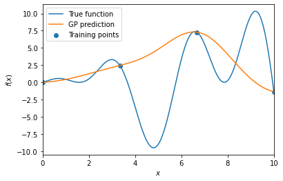

```python
# Visualizing the Gaussian Process Prediction
y_gpr = gpr.predict(x_plot.reshape(-1, 1), return_std=False, return_cov=False)
plt.xlabel('$x$')
plt.ylabel('$f(x)$')
plt.xlim([0,10])
plt.plot(x_plot, y_plot,label="True function")#true function
plt.plot(x_plot, y_gpr,label="GP prediction")#gp prediction
plt.scatter(x_train1, y_train1,label="Training points")#training points
plt.legend(loc="upper left")
plt.show()
```

### (b) Optimize your chosen function from (a) using Bayesian optimization:

- Use the four equally spaced points from part (a) to create the initial model.
- Sample a further EIGHT points using the Expected Improvement acquisition function.
- At each iteration, print the value of x selected by the Expected Improvement acquisition function for evaluation, and the value of function evaluated at x.
- After all iterations are complete, print the best (i.e. lowest) point found (both x and the function value at x).

```python
# Now implement the initial_sample function in the Bayesian optimization loop

def initial_sample(n_init,x_low,x_high):
    x_0 = random.uniform(x_low,x_high)
    y_0 = Problem21(x_0)
    x_train = np.array([[x_0]])
    y_train = np.array([[y_0]])
    i = 1
    while i < n_init:
        x_i = random.uniform(x_low,x_high)
        y_i = Problem21(x_i)
        x_train = np.vstack((x_train,x_i))
        y_train = np.vstack((y_train,y_i))
        i = i+1
    return x_train, y_train
```

```python
n_init = 8 #Sampling the function create further 8 points
x_low = 0  #Lower bound as per Problem21
x_high = 10 #upper bound
x_train2, y_train2 = initial_sample(n_init,x_low,x_high)
print(x_train2)
print(y_train2)
```

```
[[1.61271538]
 [3.58134193]
 [2.73606694]
 [5.06699986]
 [3.16404382]
 [0.51012271]
 [5.48045656]
 [9.99955251]]
[[ 4.24770146e-03]
 [ 7.58617523e-01]
 [ 2.96381279e+00]
 [-8.59692837e+00]
 [ 3.08982414e+00]
 [ 5.15959100e-01]
 [-4.13176437e+00]
 [-1.34740589e+00]]
```

```python
# Here we have merged the two sets of datapoints into a single variable so that we can conduct baysian optimization
x_train = np.concatenate((x_train1, x_train2), axis=0)
y_train = np.concatenate((y_train1, y_train2), axis=0)
f_min = min(y_train)
```

```python
# This is the first function of baysian optimization
def expected_improvement(x,y_pred,std_dev,f_min):
    arg = f_min - y_pred
    EI_exploit = arg*norm.cdf(arg/std_dev)
    EI_explor = std_dev*norm.pdf(arg/std_dev)
    EI = EI_explor + EI_exploit
    return EI
```

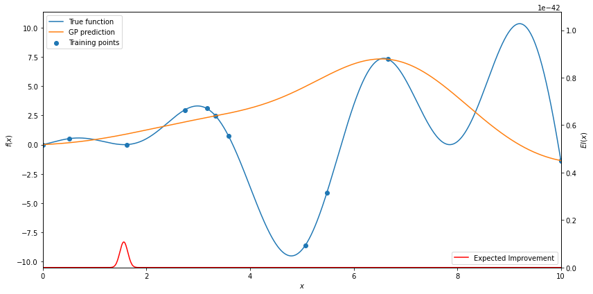

```python
# Visualizing the performance of Expected improvement performance
EI_vals = []
EI_max = -1
x_best = x_plot[0]

for x in x_plot:
    y_pred, y_std = gpr.predict(x.reshape(-1, 1), return_std=True, return_cov=False)
    EI_val = expected_improvement(x,y_pred[0][0],y_std[0],f_min)
    #if EI_val > EI_max:
         #EI_max = EI_val
         #x_best = x_val
    EI_vals.append(EI_val)

plt.rcParams["figure.figsize"] = (12,6)
fig, ax1 = plt.subplots()


ax1.set_xlabel('$x$')
ax1.set_ylabel('$f(x)$')
#ax1.set_ylim([-3,2.2])
ax1.set_xlim([0,10])
ax1.plot(x_plot, y_plot,label="True function") #true function
ax1.plot(x_plot, y_gpr,label="GP prediction") #Gaussian process prediction
#ax1.axvline(x=x_best, color='g', linestyle='--')
ax1.scatter(x_train, y_train,label="Training points")#Training points
ax1.tick_params(axis='y')

ax2 = ax1.twinx()

ax2.set_ylabel('$EI(x)$')
ax2.plot(x_plot, EI_vals,color='red',label="Expected Improvement")
ax2.tick_params(axis='y')
ax2.set_ylim(0,max(EI_vals)*10)

fig.tight_layout() # otherwise the right y-label is slightly clipped
ax1.legend(loc="upper left")
ax2.legend(loc="lower right")
plt.show()
```

```python
# This is the second function which will help us find the best coordinates that will fit in the function
def maximize_acquisition_function(gpr,x_train,y_train,f_min,x_low,x_high):
    n_grid_points = 2000
    x_grid = np.linspace(x_low,x_high,n_grid_points)

    EI_max = -1
    x_next = x_grid[0]

    for x_val in x_grid:
        y_pred, y_std = gpr.predict(x_val.reshape(-1, 1), return_std=True, return_cov=False)
        EI_val = expected_improvement(x,y_pred[0][0],y_std[0],f_min)

    if EI_val > EI_max:
        EI_max = EI_val
        x_next = x_val
    return x_next
```

```python
# This is the final function which iterates and tries to find the best value of x and y
def evaluate_x_next(x_next):
    y_next = Problem21(x_next)
    return y_next
```

```python
# Bayesian optimization loop
iter_max = 20
iteration = 0

#x_train, y_train = initial_sample(n_init,x_low,x_high)
x_best = float(min(x_train))
y_best = float(min(y_train))

while iteration < iter_max:
    gp = train_gaussian_process(x_train,y_train)

    x_next = maximize_acquisition_function(gp,x_train,y_train,y_best,x_low,x_high)
    y_next = evaluate_x_next(x_next)

    if y_next < y_best:
            y_best = y_next
            x_best = x_next

    x_train = np.vstack((x_train,x_next))
    y_train = np.vstack((y_train,y_next))
    iteration = iteration + 1
    print(iteration,x_next,y_next)

print("Best point found: ",x_best,y_best)
```

```
1 10.0 -1.359390490759778
2 10.0 -1.359390490759778
3 10.0 -1.359390490759778
4 10.0 -1.359390490759778
5 10.0 -1.359390490759778
6 10.0 -1.359390490759778
7 10.0 -1.359390490759778
8 10.0 -1.359390490759778
9 10.0 -1.359390490759778
10 10.0 -1.359390490759778
11 10.0 -1.359390490759778
12 10.0 -1.359390490759778
13 10.0 -1.359390490759778
14 10.0 -1.359390490759778
15 10.0 -1.359390490759778
16 10.0 -1.359390490759778
17 10.0 -1.359390490759778
18 10.0 -1.359390490759778
19 10.0 -1.359390490759778
20 10.0 -1.359390490759778
Best point found:  0.0 -8.596928368531188
```

Using the same function selected in part (a), carry out Bayesian optimization using:

- SIX initial points, plus SIX points selected using Expected Improvement
- EIGHT initial points, plus FOUR points selected using Expected Improvement

In each case, the initial points should be equally spaced between the lower and upper bounds of the domain of the function. The upper and lower bounds of the domain should be included in the sampled points.

```python
x_train1 = np.array([np.linspace(0, 10, 6)]).T
y_train1 = np.array([[Problem21(x_train1[0][0]),Problem21(x_train1[1][0]),Problem21(x_train1[2][0]),
Problem21(x_train1[3][0]),Problem21(x_train1[4][0]),Problem21(x_train1[5][0])]]).T
print(x_train1)
print(y_train1)
```

```
[[ 0.]
 [ 2.]
 [ 4.]
 [ 6.]
 [ 8.]
 [10.]]
[[ 0.        ]
 [ 0.51130761]
 [-3.60921012]
 [ 3.38663076]
 [ 0.25359013]
 [-1.35939049]]
```

```python
n_init = 6 #Sampling the function create further 8 points
x_low = 0  #Lower bound as per Problem21
x_high = 10 #upper bound
x_train2, y_train2 = initial_sample(n_init,x_low,x_high)
print(x_train2)
print(y_train2)
```

```
[[0.83678389]
 [7.83481344]
 [8.24967751]
 [6.24868198]
 [0.79918071]
 [1.1612774 ]]
[[5.35459687e-01]
 [4.31733598e-03]
 [1.81387773e+00]
 [6.01825248e+00]
 [5.50814080e-01]
 [2.72189620e-01]]
```

```python
x_train = np.concatenate((x_train1, x_train2), axis=0)
y_train = np.concatenate((y_train1, y_train2), axis=0)
f_min = min(y_train)
```

```python
# Bayesian optimization loop
iter_max = 20
iteration = 0

#x_train, y_train = initial_sample(n_init,x_low,x_high)
x_best = float(min(x_train))
y_best = float(min(y_train))

while iteration < iter_max:
    gp = train_gaussian_process(x_train,y_train)

    x_next = maximize_acquisition_function(gp,x_train,y_train,y_best,x_low,x_high)
    y_next = evaluate_x_next(x_next)

    if y_next < y_best:
            y_best = y_next
            x_best = x_next

    x_train = np.vstack((x_train,x_next))
    y_train = np.vstack((y_train,y_next))
    iteration = iteration + 1
    print(iteration,x_next,y_next)

print("Best point found: ",x_best,y_best)
```

```
1 10.0 -1.359390490759778
2 10.0 -1.359390490759778
3 10.0 -1.359390490759778
4 10.0 -1.359390490759778
5 10.0 -1.359390490759778
6 10.0 -1.359390490759778
7 10.0 -1.359390490759778
8 10.0 -1.359390490759778
9 10.0 -1.359390490759778
10 10.0 -1.359390490759778
11 10.0 -1.359390490759778
12 10.0 -1.359390490759778
13 10.0 -1.359390490759778
14 10.0 -1.359390490759778
15 10.0 -1.359390490759778
16 10.0 -1.359390490759778
17 10.0 -1.359390490759778
18 10.0 -1.359390490759778
19 10.0 -1.359390490759778
20 10.0 -1.359390490759778
Best point found:  0.0 -3.609210116466167
```

```python
x_train1 = np.array([np.linspace(0, 10, 8)]).T
y_train1 = np.array([[Problem21(x_train1[0][0]),Problem21(x_train1[1][0]),Problem21(x_train1[2][0]),
Problem21(x_train1[3][0]),Problem21(x_train1[4][0]),Problem21(x_train1[5][0]),Problem21(x_train1[6][0]),Problem21(x_train1[7][0])]]).T
print(x_train1)
print(y_train1)
```

```
[[ 0.        ]
 [ 1.42857143]
 [ 2.85714286]
 [ 4.28571429]
 [ 5.71428571]
 [ 7.14285714]
 [ 8.57142857]
 [10.        ]]
[[ 0.        ]
 [ 0.04298125]
 [ 3.2089248 ]
 [-6.71918598]
 [-0.68064036]
 [ 4.35447703]
 [ 5.29716198]
 [-1.35939049]]
```

```python
n_init = 4 #Sampling the function create further 8 points
x_low = 0  #Lower bound as per Problem21
x_high = 10 #upper bound
x_train2, y_train2 = initial_sample(n_init,x_low,x_high)
print(x_train2)
print(y_train2)
```

```
[[2.21705969]
 [2.45836831]
 [3.82626614]
 [2.50050564]]
[[ 1.16095747]
 [ 2.05083312]
 [-1.65421172]
 [ 2.20719324]]
```

```python
x_train = np.concatenate((x_train1, x_train2), axis=0)
y_train = np.concatenate((y_train1, y_train2), axis=0)
f_min = min(y_train)
```

```python
# Bayesian optimization loop
iter_max = 20
iteration = 0

#x_train, y_train = initial_sample(n_init,x_low,x_high)
x_best = float(min(x_train))
y_best = float(min(y_train))

while iteration < iter_max:
    gp = train_gaussian_process(x_train,y_train)

    x_next = maximize_acquisition_function(gp,x_train,y_train,y_best,x_low,x_high)
    y_next = evaluate_x_next(x_next)

    if y_next < y_best:
            y_best = y_next
            x_best = x_next

    x_train = np.vstack((x_train,x_next))
    y_train = np.vstack((y_train,y_next))
    iteration = iteration + 1
    print(iteration,x_next,y_next)

print("Best point found: ",x_best,y_best)
```

```
1 10.0 -1.359390490759778
2 10.0 -1.359390490759778
3 10.0 -1.359390490759778
4 10.0 -1.359390490759778
5 10.0 -1.359390490759778
6 10.0 -1.359390490759778
7 10.0 -1.359390490759778
8 10.0 -1.359390490759778
9 10.0 -1.359390490759778
10 10.0 -1.359390490759778
11 10.0 -1.359390490759778
12 10.0 -1.359390490759778
13 10.0 -1.359390490759778
14 10.0 -1.359390490759778
15 10.0 -1.359390490759778
16 10.0 -1.359390490759778
17 10.0 -1.359390490759778
18 10.0 -1.359390490759778
19 10.0 -1.359390490759778
20 10.0 -1.359390490759778
Best point found:  0.0 -6.7191859814688915
```

### Part 2 Supervised Learning

The dataset that we will use for this task will be provided and you can downland it from the Blackboard. The dataset includes three files for three exercises. The 1st, 5th and 9th columns (with long data like 2107727051) are time stamps when the data were collected, while other columns contain readings from different sensors. The classification problem is to predict the type of exercise. In this task, you are required to use k fold cross-validation.

#### 1. [Pre-processing]

In this step, you will be focussing on preparing the datasets, i.e. loading, exploring the datasets, displaying, reorganising data, removing noise and normalisation etc. **[3 marks]**

#### Loading the datasets

```python
# load data from each csv files and assign new DataFrame names to each
# read_csv with iso-8859-1 encoding

ex1 = pd.read_csv('EX1_Pectoral.csv', encoding='iso-8859-1', header = None)
ex2 = pd.read_csv('Ex2_ArmCurl.csv', encoding='iso-8859-1', header = None)
ex3 = pd.read_csv('EX3_LatPull.csv', encoding='iso-8859-1', header = None)

# Copy each to new DF names so that we can have a copy of the original imports if needed
Pectoral = ex1.copy()
Arm_Curl = ex2.copy()
Lat_Pull = ex3.copy()
```

```python
Pectoral.head() ### Viewing first 5 rows
```

|  | 0 | 1 | 2 | 3 | 4 | 5 | 6 | 7 | 8 | 9 | 10 | 11 | 12 |
| --- | --- | --- | --- | --- | --- | --- | --- | --- | --- | --- | --- | --- | --- |
| 0 | 2126190185 | 9.981 | -2.207 | 0.723 | 2126190185 | 0.168 | -0.016 | 0.237 | 2126190185 | -0.272 | 0.026 | -0.385 | -0.882 |
| 1 | 2155548095 | 8.833 | -3.251 | 4.687 | 2155548095 | -0.064 | 0.003 | 0.186 | 2155548095 | 0.159 | -0.007 | -0.464 | 0.871 |
| 2 | 2466796875 | 8.679 | -0.120 | 3.691 | 2462615966 | 0.826 | 0.077 | 0.237 | 2462615966 | 0.259 | 0.024 | 0.074 | -0.963 |
| 3 | 2483459472 | 8.124 | -0.934 | 5.175 | 2483459472 | 0.583 | 0.027 | 0.426 | 2483459472 | -0.481 | -0.022 | -0.351 | 0.803 |
| 4 | 2514190673 | 8.919 | -3.097 | 3.193 | 2514190673 | 0.469 | -0.051 | 0.490 | 2514190673 | 0.641 | -0.069 | 0.670 | -0.367 |

#### Labelling each dataset

```python
Pectoral['label'] = 1
```

```python
Arm_Curl.head()
```

|  | 0 | 1 | 2 | 3 | 4 | 5 | 6 | 7 | 8 | 9 | 10 | 11 | 12 |
| --- | --- | --- | --- | --- | --- | --- | --- | --- | --- | --- | --- | --- | --- |
| 0 | 2097503662 | -0.158 | 2.992 | 8.057 | 2097503662 | -0.429 | 0.059 | 0.160 | 2097503662 | 0.927 | -0.127 | -0.346 | 0.065 |
| 1 | 2126495361 | -0.062 | 2.619 | 7.866 | 2126495361 | -0.961 | 0.107 | 0.312 | 2126495361 | -0.921 | 0.102 | 0.299 | 0.226 |
| 2 | 2436340332 | -6.774 | -2.523 | 4.495 | 2436340332 | -2.882 | 2.139 | 1.236 | 2436340332 | 0.644 | -0.478 | -0.276 | 0.530 |
| 3 | 2797210693 | -3.538 | -6.267 | 6.525 | 2797210693 | 0.482 | 0.597 | -0.056 | 2797210693 | -0.057 | -0.070 | 0.007 | -0.996 |
| 4 | 2858093261 | -3.997 | -6.065 | 6.812 | 2858093261 | 0.131 | 0.317 | 0.040 | 2858093261 | -0.000 | -0.001 | -0.000 | -1.000 |

```python
Arm_Curl['label'] = 2
```

```python
Lat_Pull.head()
```

|  | 0 | 1 | 2 | 3 | 4 | 5 | 6 | 7 | 8 | 9 | 10 | 11 | 12 |
| --- | --- | --- | --- | --- | --- | --- | --- | --- | --- | --- | --- | --- | --- |
| 0 | 3038208008 | -0.158 | 0.905 | 10.183 | 3038208008 | 1.097 | -0.067 | 0.216 | 3038208008 | -0.537 | 0.033 | -0.106 | -0.836 |
| 1 | 3109527588 | 0.330 | -2.370 | 9.378 | 3105377197 | -0.802 | 0.226 | -0.658 | 3105377197 | -0.498 | 0.141 | -0.409 | -0.752 |
| 2 | 3508972168 | 3.241 | -5.185 | 8.794 | 3505737305 | 1.630 | -1.665 | -0.655 | 3505737305 | 0.668 | -0.682 | -0.269 | -0.125 |
| 3 | 3693756103 | 4.246 | -6.583 | 8.143 | 3693756103 | 0.306 | -1.292 | -0.509 | 3693756103 | 0.089 | -0.376 | -0.148 | 0.911 |
| 4 | 3784240723 | 5.434 | -2.456 | 6.851 | 3776092529 | 0.863 | -1.491 | -0.503 | 3776092529 | -0.449 | 0.775 | 0.262 | -0.360 |

```python
Lat_Pull['label'] = 3
```

#### Merging the Dataset

```python
# After labelling the dataset we have merged the 3 datasets into a single dataframe
pdList = [Pectoral, Arm_Curl,Lat_Pull]  # List of your dataframes
final_df = pd.concat(pdList)
```

```python
final_df.head()
```

|  | 0 | 1 | 2 | 3 | 4 | 5 | 6 | 7 | 8 | 9 | 10 | 11 | 12 | label |
| --- | --- | --- | --- | --- | --- | --- | --- | --- | --- | --- | --- | --- | --- | --- |
| 0 | 2126190185 | 9.981 | -2.207 | 0.723 | 2126190185 | 0.168 | -0.016 | 0.237 | 2126190185 | -0.272 | 0.026 | -0.385 | -0.882 | 1 |
| 1 | 2155548095 | 8.833 | -3.251 | 4.687 | 2155548095 | -0.064 | 0.003 | 0.186 | 2155548095 | 0.159 | -0.007 | -0.464 | 0.871 | 1 |
| 2 | 2466796875 | 8.679 | -0.120 | 3.691 | 2462615966 | 0.826 | 0.077 | 0.237 | 2462615966 | 0.259 | 0.024 | 0.074 | -0.963 | 1 |
| 3 | 2483459472 | 8.124 | -0.934 | 5.175 | 2483459472 | 0.583 | 0.027 | 0.426 | 2483459472 | -0.481 | -0.022 | -0.351 | 0.803 | 1 |
| 4 | 2514190673 | 8.919 | -3.097 | 3.193 | 2514190673 | 0.469 | -0.051 | 0.490 | 2514190673 | 0.641 | -0.069 | 0.670 | -0.367 | 1 |

#### Renaming Columns of the Dataset

```python
# Here we are giving names to each column to give it more meaning
final_df.rename(columns={final_df.columns[0]: 'Timestamp 1', final_df.columns[1]: 'Sensor 1',
                        final_df.columns[2]: 'Sensor 2',final_df.columns[3]: 'Sensor 3',final_df.columns[4]: 'Timestamp 2',
                        final_df.columns[5]: 'Sensor 4',final_df.columns[6]: 'Sensor 5',final_df.columns[7]: 'Sensor 6',
                        final_df.columns[8]: 'Timestamp 3',final_df.columns[9]: 'Sensor 7',final_df.columns[10]: 'Sensor 8',
                        final_df.columns[11]: 'Sensor 9', final_df.columns[12]: 'Sensor 10'},inplace=True)
```

```python
# Viewing the first 5 rows of the final merged dataframe
final_df.head()
```

|  | Timestamp 1 | Sensor 1 | Sensor 2 | Sensor 3 | Timestamp 2 | Sensor 4 | Sensor 5 | Sensor 6 | Timestamp 3 | Sensor 7 | Sensor 8 | Sensor 9 | Sensor 10 | label |
| --- | --- | --- | --- | --- | --- | --- | --- | --- | --- | --- | --- | --- | --- | --- |
| 0 | 2126190185 | 9.981 | -2.207 | 0.723 | 2126190185 | 0.168 | -0.016 | 0.237 | 2126190185 | -0.272 | 0.026 | -0.385 | -0.882 | 1 |
| 1 | 2155548095 | 8.833 | -3.251 | 4.687 | 2155548095 | -0.064 | 0.003 | 0.186 | 2155548095 | 0.159 | -0.007 | -0.464 | 0.871 | 1 |
| 2 | 2466796875 | 8.679 | -0.120 | 3.691 | 2462615966 | 0.826 | 0.077 | 0.237 | 2462615966 | 0.259 | 0.024 | 0.074 | -0.963 | 1 |
| 3 | 2483459472 | 8.124 | -0.934 | 5.175 | 2483459472 | 0.583 | 0.027 | 0.426 | 2483459472 | -0.481 | -0.022 | -0.351 | 0.803 | 1 |
| 4 | 2514190673 | 8.919 | -3.097 | 3.193 | 2514190673 | 0.469 | -0.051 | 0.490 | 2514190673 | 0.641 | -0.069 | 0.670 | -0.367 | 1 |

#### Viewing datatype and null values in dataset

```python
final_df.info()
```

```
<class 'pandas.core.frame.DataFrame'>
Int64Index: 2022 entries, 0 to 285
Data columns (total 14 columns):
 #   Column       Non-Null Count  Dtype
---  ------       --------------  -----
 0   Timestamp 1  2022 non-null   int64
 1   Sensor 1     2022 non-null   float64
 2   Sensor 2     2022 non-null   float64
 3   Sensor 3     2022 non-null   float64
 4   Timestamp 2  2022 non-null   int64
 5   Sensor 4     2022 non-null   float64
 6   Sensor 5     2022 non-null   float64
 7   Sensor 6     2022 non-null   float64
 8   Timestamp 3  2022 non-null   int64
 9   Sensor 7     2022 non-null   float64
 10  Sensor 8     2022 non-null   float64
 11  Sensor 9     2022 non-null   float64
 12  Sensor 10    2022 non-null   float64
 13  label        2022 non-null   int64
dtypes: float64(10), int64(4)
memory usage: 237.0 KB
```

#### Showing Statistical Description of each column in the dataset

```python
final_df.describe()
```

|  | Timestamp 1 | Sensor 1 | Sensor 2 | Sensor 3 | Timestamp 2 | Sensor 4 | Sensor 5 | Sensor 6 | Timestamp 3 | Sensor 7 | Sensor 8 | Sensor 9 | Sensor 10 | label |
| --- | --- | --- | --- | --- | --- | --- | --- | --- | --- | --- | --- | --- | --- | --- |
| count | 2.022000e+03 | 2022.000000 | 2022.000000 | 2022.000000 | 2.022000e+03 | 2022.000000 | 2022.000000 | 2022.000000 | 2.022000e+03 | 2022.000000 | 2022.000000 | 2022.000000 | 2022.000000 | 2022.000000 |
| mean | 1.842206e+10 | 5.973671 | -2.335846 | 1.888528 | 1.842162e+10 | -0.033541 | 0.005218 | 0.033234 | 1.842162e+10 | 0.014695 | 0.002477 | 0.002784 | -0.025250 | 1.545500 |
| std | 9.648946e+09 | 4.933680 | 2.025704 | 5.524675 | 9.648919e+09 | 0.963943 | 1.044151 | 0.564667 | 9.648919e+09 | 0.473894 | 0.369762 | 0.345931 | 0.710502 | 0.728753 |
| min | 2.097504e+09 | -19.604000 | -19.556000 | -19.604000 | 2.097504e+09 | -9.588000 | -5.577000 | -2.570000 | 2.097504e+09 | -0.975000 | -0.999000 | -0.959000 | -1.000000 | 1.000000 |
| 25% | 1.058852e+10 | 4.739750 | -3.538000 | 1.737750 | 1.058852e+10 | -0.218000 | -0.115000 | -0.250000 | 1.058852e+10 | -0.258750 | -0.112000 | -0.218500 | -0.725750 | 1.000000 |
| 50% | 1.721976e+10 | 7.961000 | -2.274000 | 4.084000 | 1.721976e+10 | 0.109000 | -0.013000 | 0.125000 | 1.721976e+10 | 0.000000 | 0.000000 | -0.001000 | -0.086500 | 1.000000 |
| 75% | 2.493780e+10 | 8.603000 | -1.527000 | 4.897000 | 2.493587e+10 | 0.482000 | 0.149000 | 0.336000 | 2.493587e+10 | 0.308000 | 0.099000 | 0.227750 | 0.705750 | 2.000000 |
| max | 3.880441e+10 | 16.521000 | 15.123000 | 19.594000 | 3.880441e+10 | 4.722000 | 4.107000 | 4.229000 | 3.880441e+10 | 0.994000 | 0.997000 | 0.959000 | 1.000000 | 3.000000 |

#### Checking for missing values

```python
percent_missing = final_df.isnull().sum() * 100 / len(final_df)
percent_missing = round(percent_missing, 2)
percent_missing = percent_missing.astype(str) + '%'
percent_missing
```

```
Timestamp 1    0.0%
Sensor 1       0.0%
Sensor 2       0.0%
Sensor 3       0.0%
Timestamp 2    0.0%
Sensor 4       0.0%
Sensor 5       0.0%
Sensor 6       0.0%
Timestamp 3    0.0%
Sensor 7       0.0%
Sensor 8       0.0%
Sensor 9       0.0%
Sensor 10      0.0%
label          0.0%
dtype: object
```

#### Checking for any duplicate rows

```python
dup_percentage = final_df.duplicated().sum()/len(final_df)*100
dup_percentage = round(dup_percentage,2)
dup_percentage = dup_percentage.astype(str) + '%'
dup_percentage
```

```
'0.0%'
```

#### Dealing with outliers using IQR method

In this method we calculate the lower and upper quartiles and then calculate the interquartile range. All the values that do no lie in the range are omitted. We did this as per need on all the features in the given dataset.

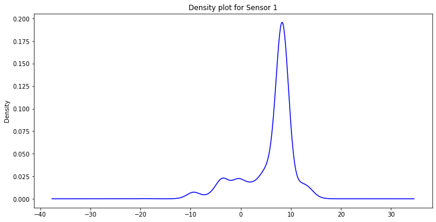

```python
final_df['Sensor 1'].plot.density(color='blue')
plt.title('Density plot for Sensor 1')
plt.show()
```

```python
q3, q1 = np.percentile(final_df['Sensor 1'], [75 ,25])
iqr = q3-q1
𝐿𝐵 = q1 - 1.5 * iqr
𝑈𝐵 = q3 + 1.5 * iqr
final_df = final_df[(final_df['Sensor 1'] >= LB) & (final_df['Sensor 1'] <= UB)]
```

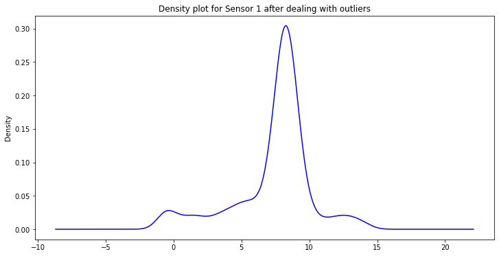

```python
final_df['Sensor 1'].plot.density(color='blue')
plt.title('Density plot for Sensor 1 after dealing with outliers')
plt.show()
```

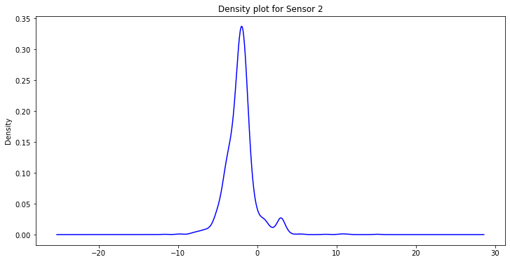

```python
final_df['Sensor 2'].plot.density(color='blue')
plt.title('Density plot for Sensor 2')
plt.show()
```

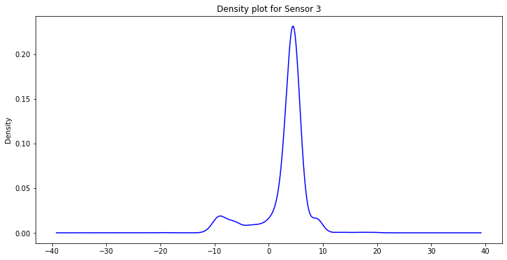

```python
final_df['Sensor 3'].plot.density(color='blue')
plt.title('Density plot for Sensor 3')
plt.show()
```

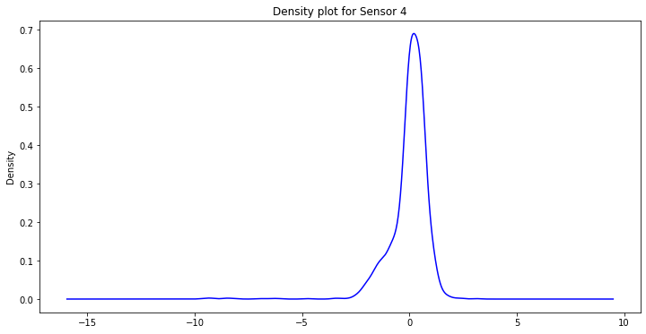

```python
final_df['Sensor 4'].plot.density(color='blue')
plt.title('Density plot for Sensor 4')
plt.show()
```

```python
q3, q1 = np.percentile(final_df['Sensor 4'], [75 ,25])
iqr = q3-q1
𝐿𝐵 = q1 - 1.5 * iqr
𝑈𝐵 = q3 + 1.5 * iqr
final_df = final_df[(final_df['Sensor 4'] >= LB) & (final_df['Sensor 4'] <= UB)]
```

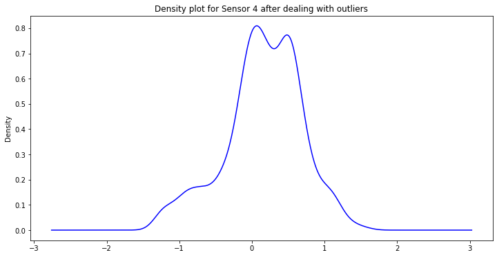

```python
final_df['Sensor 4'].plot.density(color='blue')
plt.title('Density plot for Sensor 4 after dealing with outliers')
plt.show()
```

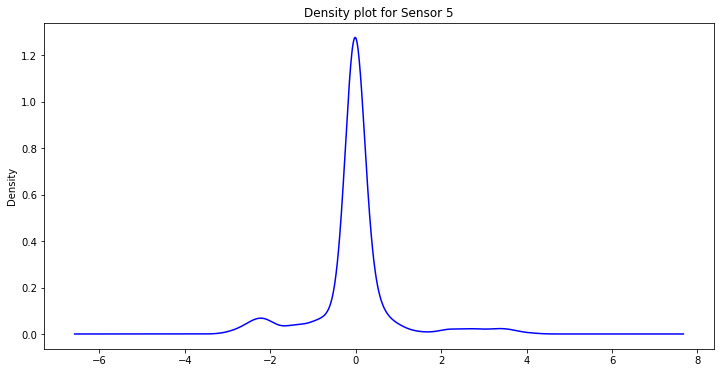

```python
final_df['Sensor 5'].plot.density(color='blue')
plt.title('Density plot for Sensor 5')
plt.show()
```

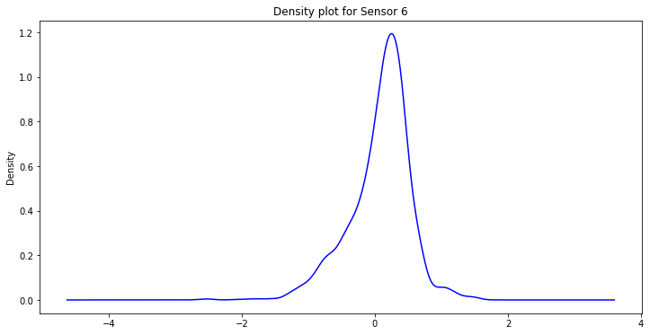

```python
final_df['Sensor 6'].plot.density(color='blue')
plt.title('Density plot for Sensor 6')
plt.show()
```

[figure not shown]

```python
final_df['Sensor 7'].plot.density(color='blue')
plt.title('Density plot for Sensor 4')
plt.show()
```

[figure not shown]

```python
final_df['Sensor 8'].plot.density(color='blue')
plt.title('Density plot for Sensor 4')
plt.show()
```

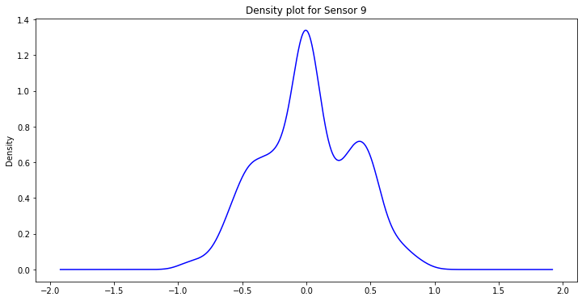

```python
final_df['Sensor 9'].plot.density(color='blue')
plt.title('Density plot for Sensor 9')
plt.show()
```

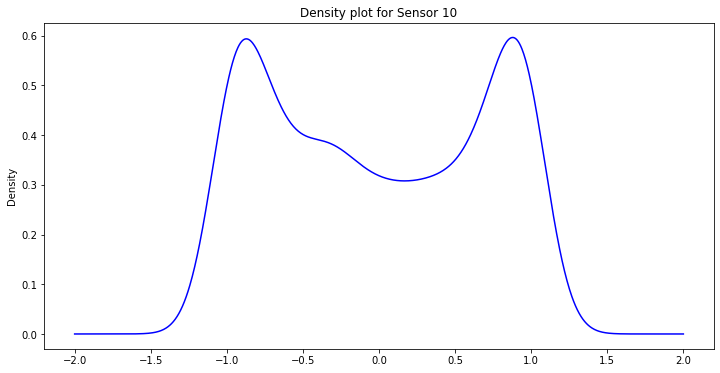

```python
final_df['Sensor 10'].plot.density(color='blue')
plt.title('Density plot for Sensor 10')
plt.show()
```

#### 2. [Features Extraction]

Extract the features you will need for the remainder of the analysis. You may revisit this stage many times as you become more familiar with the dataset and the kinds of features that may be useful for the classification task. The features you choose may affect the performance of the final classifier. Choose something you think is reasonable to start with and later you can experiment with alternatives on the test set. **[4 marks]**

#### Viewing the correlation of features

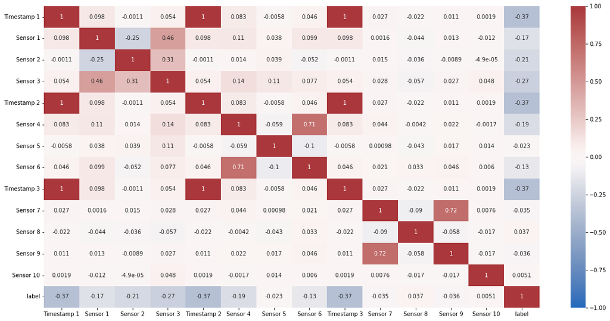

```python
plt.figure(figsize=(20, 10))
heatmap = sns.heatmap(final_df.corr(), vmin=-1, vmax=1, annot=True, cmap='vlag')
```

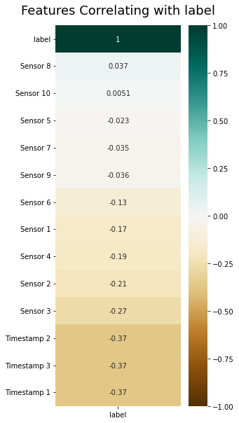

```python
plt.figure(figsize=(4, 10))
heatmap = sns.heatmap(final_df.corr()[['label']].sort_values(by='label', ascending=False), vmin=-1, vmax=1, annot=True, cmap='BrBG')
heatmap.set_title('Features Correlating with label', fontdict={'fontsize':18}, pad=16)
```

#### Defining Dependant (y) and independant (X) variables

```python
# After viewing the correlation between the features we decided to keep all features as X and target feature as Y
X = final_df.drop(['label'],axis=1)
y = final_df['label']
```

#### Train/Test Split

```python
# 70% training and 30% test
X_train, X_test, y_train, y_test = train_test_split(X, y, test_size=0.3, random_state=1, stratify = y)
```

#### 3. [Supervised classification]

Use KNN and SVM to build the exercise classification model, using k fold cross-validation in training the model and testing.

- You shall demonstrate the selection of k value has been carefully considered.
- Tune the parameters of the classification models and identify the optimal settings.
- Compare the performance of the two classification models using confusion matrix, accuracy, precision, recall, specificity, F1-score and AUC. Summarise the results using tables or figures.

#### Create a PipeLine that contains both a StandardScaler and a KNN model

```python
scaler = StandardScaler()
knn = KNeighborsClassifier()
operations = [('scaler',scaler),('knn',knn)]
pipe = Pipeline(operations)
```

#### Perform a grid-search with the pipeline to test various values of k and report back the best performing parameters.

```python
k_values = list(range(1,30))
param_grid = {'knn__n_neighbors': k_values}
optimal_classifier = GridSearchCV(pipe,param_grid,cv=5,scoring='accuracy')
```

```python
optimal_classifier.fit(X_train,y_train)
```

```
GridSearchCV(cv=5,
             estimator=Pipeline(steps=[('scaler', StandardScaler()),
                                       ('knn', KNeighborsClassifier())]),
             param_grid={'knn__n_neighbors': [1, 2, 3, 4, 5, 6, 7, 8, 9, 10, 11,
                                              12, 13, 14, 15, 16, 17, 18, 19,
                                              20, 21, 22, 23, 24, 25, 26, 27,
                                              28, 29]},
             scoring='accuracy')
```

```python
optimal_classifier.best_estimator_.get_params()
```

```
{'memory': None,
 'steps': [('scaler', StandardScaler()),
  ('knn', KNeighborsClassifier(n_neighbors=1))],
 'verbose': False,
 'scaler': StandardScaler(),
 'knn': KNeighborsClassifier(n_neighbors=1),
 'scaler__copy': True,
 'scaler__with_mean': True,
 'scaler__with_std': True,
 'knn__algorithm': 'auto',
 'knn__leaf_size': 30,
 'knn__metric': 'minkowski',
 'knn__metric_params': None,
 'knn__n_jobs': None,
 'knn__n_neighbors': 1,
 'knn__p': 2,
 'knn__weights': 'uniform'}
```

```python
optimal_classifier.cv_results_['mean_test_score']
```

```
array([0.95711331, 0.94312802, 0.94400904, 0.9387612 , 0.94400521,
       0.94138512, 0.94226232, 0.93439056, 0.93789933, 0.93614878,
       0.93439822, 0.93176664, 0.93089328, 0.92387574, 0.92476442,
       0.91863556, 0.91951276, 0.91601164, 0.91425343, 0.90900559,
       0.91075615, 0.90551214, 0.90288056, 0.90025282, 0.90113001,
       0.89500115, 0.89588217, 0.88975331, 0.88976097])
```

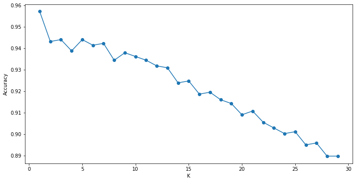

```python
scores = optimal_classifier.cv_results_['mean_test_score']
plt.plot(k_values,scores,'o-')
plt.xlabel("K")
plt.ylabel("Accuracy")
```

```python
pred = optimal_classifier.predict(X_test)
```

#### Evaluating the Model

```python
confusion_matrix(y_test,pred)
```

```
array([[318,   1,   3],
       [  1,  84,   1],
       [ 13,   3,  67]], dtype=int64)
```

```python
print(classification_report(y_test,pred))
```

```
              precision    recall  f1-score   support

           1       0.96      0.99      0.97       322
           2       0.95      0.98      0.97        86
           3       0.94      0.81      0.87        83

    accuracy                           0.96       491
   macro avg       0.95      0.92      0.94       491
weighted avg       0.95      0.96      0.95       491
```

#### SVM

```python
# Standardized X train and test
scaled_X_train = scaler.fit_transform(X_train)
scaled_X_test = scaler.transform(X_test)
```

```python
# Initialize SVM model
svc = SVC(class_weight='balanced')
```

```python
# Hyper-Tune the Model to find the best Parameters
param_grid = {'C':[0.001,0.01,0.1,0.5,1],'gamma':['scale','auto']}
grid = GridSearchCV(svc,param_grid)
```

```python
grid.fit(scaled_X_train,y_train)
```

```
GridSearchCV(estimator=SVC(class_weight='balanced'),
             param_grid={'C': [0.001, 0.01, 0.1, 0.5, 1],
                         'gamma': ['scale', 'auto']})
```

```python
grid.best_params_
```

```
{'C': 1, 'gamma': 'scale'}
```

```python
# Make predictions with best parameters
grid_pred = grid.predict(scaled_X_test)
```

```python
# Create the confusion matrix
confusion_matrix(y_test,grid_pred)
```

```
array([[311,   1,  10],
       [  0,  84,   2],
       [  4,   1,  78]], dtype=int64)
```

```python
# Print the classification report
print(classification_report(y_test,grid_pred))
```

```
              precision    recall  f1-score   support

           1       0.99      0.97      0.98       322
           2       0.98      0.98      0.98        86
           3       0.87      0.94      0.90        83

    accuracy                           0.96       491
   macro avg       0.94      0.96      0.95       491
weighted avg       0.97      0.96      0.96       491
```

#### 4. [Summary and Discussion]

Summarise your findings, discuss the factors that could have impacts on your results and propose potential improvement. **[2 marks]**

### Summary and Discussion:

In this task we were asked to apply two classification models i.e KNN and SVM.

**Task1: Data Preprocessing:** We first imported the dataset using pandas library. We then created a label column to label each excercise. After creating the label the data was then merged into a single dataframe. We then checked for any missing or duplicate values and also dealt with any potential noise in the dataset using IQR method. We also renamed the columns to make the columns more meaningful.

**Task2: Feature Extraction:** In this task we first created a heatmap to see the relationship of all the variables with our labelled data. Since we saw no significant relationship thats why we decided to choose all variables as our predictors and label variable as our target. We then split the dataset into test and train in the ratio 70:30

**Task3: Classification:** In this section we first applied KNN classification model. We created a pipeline which scaled the values in the KNN model. We the used GridSearchCV to find the best parameters for the model by testing the model on K values from 1 to 30 and choosing the optimal value of K. After that we created the confusion matrix and classification report to see the performance of our model. Based on the results we can see that the KNN model performed really well as we acheived an accuracy of 96% in successfully labelleing the data.

We then applied SVM and applied similar steps to what we did in KNN. Here we again acheived a good performance as SVM also managed to accurately predict 96% of the data correctly.

### Part 3 Unsupervised Learning (20%)

Use all the datasets provided in Part2 for clustering techniques in Part 3.

#### 1. [Data preparation]:

You shall prepare the data for clustering.

Since we will be creating classes/labels using clustering, we do now need the label column. In unsupervised learning we dont have a target variable. We create a target variable using the existing features by clustering them together.

```python
X = final_df.drop('label', axis = 1)
X.head()
```

|  | Timestamp 1 | Sensor 1 | Sensor 2 | Sensor 3 | Timestamp 2 | Sensor 4 | Sensor 5 | Sensor 6 | Timestamp 3 | Sensor 7 | Sensor 8 | Sensor 9 | Sensor 10 |
| --- | --- | --- | --- | --- | --- | --- | --- | --- | --- | --- | --- | --- | --- |
| 0 | 2126190185 | 9.981 | -2.207 | 0.723 | 2126190185 | 0.168 | -0.016 | 0.237 | 2126190185 | -0.272 | 0.026 | -0.385 | -0.882 |
| 1 | 2155548095 | 8.833 | -3.251 | 4.687 | 2155548095 | -0.064 | 0.003 | 0.186 | 2155548095 | 0.159 | -0.007 | -0.464 | 0.871 |
| 2 | 2466796875 | 8.679 | -0.120 | 3.691 | 2462615966 | 0.826 | 0.077 | 0.237 | 2462615966 | 0.259 | 0.024 | 0.074 | -0.963 |
| 3 | 2483459472 | 8.124 | -0.934 | 5.175 | 2483459472 | 0.583 | 0.027 | 0.426 | 2483459472 | -0.481 | -0.022 | -0.351 | 0.803 |
| 4 | 2514190673 | 8.919 | -3.097 | 3.193 | 2514190673 | 0.469 | -0.051 | 0.490 | 2514190673 | 0.641 | -0.069 | 0.670 | -0.367 |

```python
# Again showing descriptive statistics of each feature which we will be using in clustering process
X.describe().transpose()
```

|  | count | mean | std | min | 25% | 50% | 75% | max |
| --- | --- | --- | --- | --- | --- | --- | --- | --- |
| Timestamp 1 | 1634.0 | 1.860027e+10 | 9.810261e+09 | 2.097504e+09 | 1.062563e+10 | 1.710953e+10 | 2.529556e+10 | 3.853366e+10 |
| Sensor 1 | 1634.0 | 7.364011e+00 | 2.944764e+00 | -9.910000e-01 | 6.939250e+00 | 8.105000e+00 | 8.689000e+00 | 1.439500e+01 |
| Sensor 2 | 1634.0 | -2.058567e+00 | 1.800168e+00 | -1.182900e+01 | -2.915000e+00 | -2.082000e+00 | -1.422000e+00 | 1.512300e+01 |
| Sensor 3 | 1634.0 | 2.960966e+00 | 4.338160e+00 | -1.960400e+01 | 3.040000e+00 | 4.304000e+00 | 5.003000e+00 | 1.959400e+01 |
| Timestamp 2 | 1634.0 | 1.859978e+10 | 9.810245e+09 | 2.097504e+09 | 1.062563e+10 | 1.710953e+10 | 2.529556e+10 | 3.853366e+10 |
| Sensor 4 | 1634.0 | 1.567925e-01 | 5.313644e-01 | -1.313000e+00 | -1.150000e-01 | 1.850000e-01 | 5.250000e-01 | 1.579000e+00 |
| Sensor 5 | 1634.0 | -3.175704e-02 | 9.110795e-01 | -3.018000e+00 | -9.900000e-02 | -2.100000e-02 | 7.200000e-02 | 4.107000e+00 |
| Sensor 6 | 1634.0 | 7.822644e-02 | 4.558583e-01 | -2.570000e+00 | -1.360000e-01 | 1.610000e-01 | 3.540000e-01 | 1.542000e+00 |
| Timestamp 3 | 1634.0 | 1.859978e+10 | 9.810245e+09 | 2.097504e+09 | 1.062563e+10 | 1.710953e+10 | 2.529556e+10 | 3.853366e+10 |
| Sensor 7 | 1634.0 | 1.787944e-02 | 4.846149e-01 | -9.750000e-01 | -2.887500e-01 | 1.000000e-03 | 3.577500e-01 | 9.940000e-01 |
| Sensor 8 | 1634.0 | 4.397185e-03 | 3.366663e-01 | -9.890000e-01 | -8.900000e-02 | 0.000000e+00 | 8.600000e-02 | 9.970000e-01 |
| Sensor 9 | 1634.0 | 1.272093e-02 | 3.614900e-01 | -9.590000e-01 | -2.377500e-01 | 0.000000e+00 | 2.947500e-01 | 9.590000e-01 |
| Sensor 10 | 1634.0 | -1.040698e-02 | 7.103142e-01 | -1.000000e+00 | -7.100000e-01 | -5.000000e-02 | 7.207500e-01 | 1.000000e+00 |

#### 2. [K-means clustering]:

apply the K-means clustering algorithm to analyse the data. You shall:

- tune the parameter setting, select the optimal cluster number using the elbow method **[2 marks]**
- use clustering validity indices to confirm the selection of K value **[3 marks]**
- visualise the centroids and the clustering results. **[3 marks]**

##### Tune the parameter setting, select the optimal cluster number using the elbow method

```python
# We have standardized/normalized the values of each feature in X variable
scaled_X = scaler.fit_transform(X)
```

```python
# This function helps us find the best value of K
ssd = []

for k in range(2,30):

    model = KMeans(n_clusters=k)


    model.fit(scaled_X)

    #Sum of squared distances of samples to their closest cluster center.
    ssd.append(model.inertia_)
```

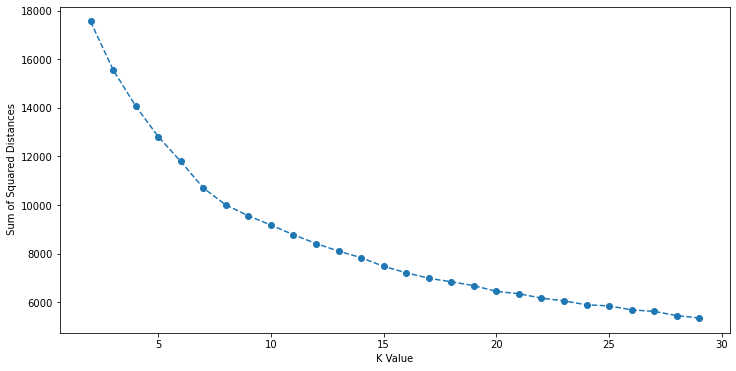

```python
# Visualizing the function above showing us the best value of k. This called the elbow method.
# Here we choose the value where we see the bending of the curve which is around 6. This is just an estimate.
# We can change the value of K to see if the performance improves.
plt.plot(range(2,30),ssd,'o--')
plt.xlabel("K Value")
plt.ylabel(" Sum of Squared Distances")
```

```python
#Initialize the class object
kmeans = KMeans(n_clusters= 6)

#predict the labels of clusters.
label = kmeans.fit_predict(scaled_X)

print(label)
```

```
[0 0 1 ... 1 1 0]
```

##### Use clustering validity indices to confirm the selection of K value

This is basically validation of the clusters created.

```python
# The minimum score is zero, with lower values indicating better clustering. Our result is not that good
print(davies_bouldin_score(scaled_X, label))
```

```
1.5478948504906136
```

The silhouette score falls within the range [-1, 1]. The silhouette score of 1 means that the clusters are very dense and nicely separated. The score of 0 means that clusters are overlapping. The score of less than 0 means that data belonging to clusters may be wrong/incorrect.

```python
silhouette_avg = silhouette_score(scaled_X, label)
silhouette_avg
```

```
0.21061973111733048
```

```python
sample_silhouett_value = silhouette_samples(scaled_X, label)
print (sample_silhouett_value)
```

```
[0.19041008 0.12971047 0.06462781 ... 0.06607044 0.0594976  0.08563459]
```

The index is the ratio of the sum of between-clusters dispersion and of within-cluster dispersion for all clusters (where dispersion is defined as the sum of distances squared). The score is higher when clusters are dense and well separated.

```python
metrics.calinski_harabasz_score(scaled_X, label)
```

```
257.37924827790596
```

##### visualise the centroids and the clustering results.

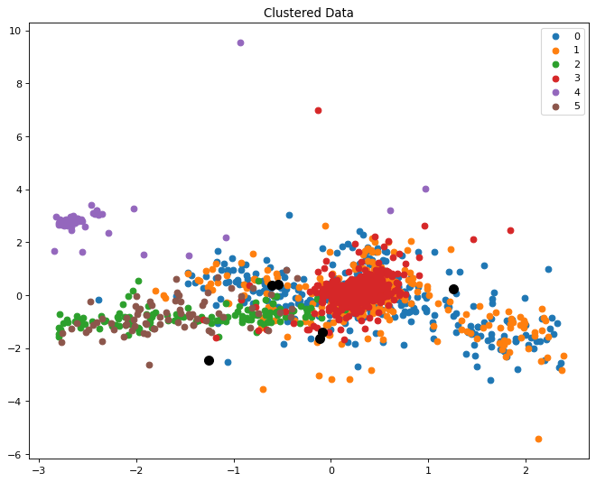

```python
#Getting unique labels and centroids
centroids = kmeans.cluster_centers_
u_labels = np.unique(label)

#plotting the results:
plt.figure(figsize=(10, 8), dpi=80)
for i in u_labels:
    plt.scatter(scaled_X[label == i , 1] , scaled_X[label == i , 2] , label = i)
plt.legend()
plt.scatter(centroids[:,0],centroids[:,1],s =80,color = 'k')
plt.title('Clustered Data')
plt.show()
```

#### 3. [Hierarchical clustering]:

apply the hierarchical clustering algorithm to analyse the data. You shall

- tune the parameters,
- visualise clustering results, and
- calculate clustering validity indices, and also display the results. **[6 marks]**

```python
# Creating the Hierarchial model and fitting the Normalized X values in it
cluster = AgglomerativeClustering(n_clusters = 6, linkage = 'complete')
label_h = cluster.fit_predict(scaled_X)
```

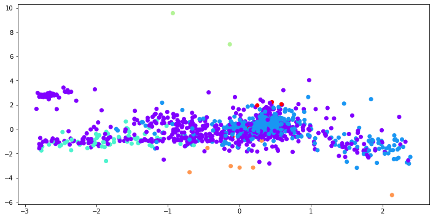

```python
# Visualizing the clusters (Very poor as they are overlapping)
plt.scatter(scaled_X[:,1],scaled_X[:,2], c=cluster.labels_, cmap='rainbow')
```

```python
# This matrix will be used to create the dendogram (This was taken from the sklearn library that has been referenced)
dist_matrix = distance_matrix(scaled_X,scaled_X)
```

```python
# Creating the linkage
Z = linkage(dist_matrix, 'complete')
```

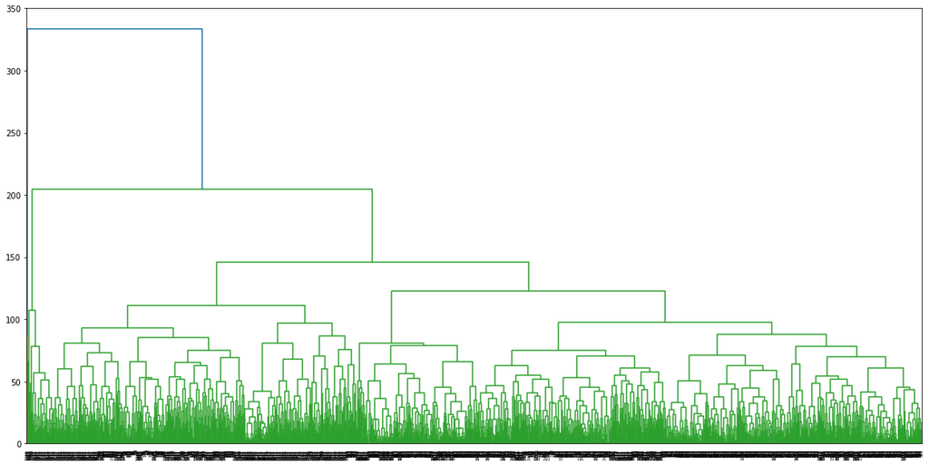

```python
# Plotting the dendogram
plt.rcParams["figure.figsize"] = (20,10)
dendro = hierarchy.dendrogram(Z)
```

##### calculate clustering validity indices, and also display the results.

This is the same thing as we did with K-Means. But form the looks of it we already know it did a very poor job.

```python
metrics.calinski_harabasz_score(scaled_X, label_h)
```

```
64.4802514527472
```

```python
print(davies_bouldin_score(scaled_X, label_h))
```

```
1.8762945706907026
```

```python
silhouette_avg = silhouette_score(scaled_X, label_h)
silhouette_avg
```

```
0.08758162379109172
```

#### 4. [Evaluation]

Evaluate the performance of these two clustering methods by comparing the clustering results with the known exercise type information.

The two clustering method implemented are Kmeans and Hierarchial. We first applied K means cluster. We determined the number of clusters using the elbow method. Based on the diagram we determined that we should create atleast 6 clusters. After creating the clusters we evaluated the clusters using 3 method, davies_bouldin, silhouette and calinski_harabasz_scores. Based on the results we saw that we did not acheive an ideal cluster. better clusters could have been obtained if we had done PCA first and then applied the clusters. The next cluster algorithm applied is Hierarchial cluster. We again visualised the model using a dendogram and then evaluated the performance of the model using the same metrics. Based on the metrics we saw that hierchial clustering did a worse job than kmeans cluster.

### References:

- https://docs.scipy.org/doc/scipy/reference/generated/scipy.cluster.hierarchy.linkage.html
- https://docs.scipy.org/doc/scipy/reference/generated/scipy.cluster.hierarchy.dendrogram.html
- https://www.askpython.com/python/examples/plot-k-means-clusters-python
- https://seaborn.pydata.org/tutorial/color_palettes.html
- https://stackoverflow.com/questions/332289/how-do-i-change-the-size-of-figures-drawn-with-matplotlib
- https://scikit-learn.org/stable/modules/generated/sklearn.model_selection.GridSearchCV.html
- Notes and Lab Solutions of Week 6,7,9,10,11